# Final

Christophe

December 13, 2015

IS 606 Fall 2015 - Final Exam

### Part I

#### Figure A below represents the distribution of an observed variable. Figure B below represents the distribution of the mean from 500 random samples of size 30 from A. The mean of A is 5.05 and the mean of B is 5.04. The standard deviations of A and B are 3.22 and 0.58, respectively

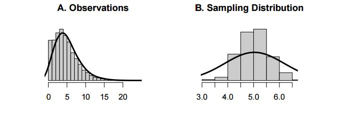

#### a. Describe the two distributions.

> The `Figure A` distribution is unimodal and right skewed. As previously stated the mean is 5.05 and this mean is to the right of the mode.

> The `Figure B` distribution is unimodal and symetrical. As previously stated the mean is 5.04 and the distribution is symetrically distributed around the mean.

##### b. Explain why the means of these two distributions are similar but the standard deviations are not.

> The means are similar because `Figure B` is a sampling distribution of `Figure A`. The expectation is that `Figure B` would have approximately the same mean as `Figure A` because `Figure B` is drawing from the population of Figure A. However, the standard deviations are dissimilar because of the distribution of observed values. In `Figure A` we have observations as high as 15 and as low as 0 which means there is a large variances in observable values. Whereas `Figure B` has a much more narrow distribution of values from 3 to approximately 7.

##### c. What is the statistical principal that describes this phenomenon?

> The statistical principle at play here is the Central Limit Theorem. We expect the sampling distribution to be normally distributed around a mean that would be very closely match the mean of the original population.

Part II Consider the four datasets, each with two columns (x and y), provided below.

```r
options(digits=2)
data1 <- data.frame(x=c(10,8,13,9,11,14,6,4,12,7,5),
y=c(8.04,6.95,7.58,8.81,8.33,9.96,7.24,4.26,10.84,4.82,5.68))
data2 <- data.frame(x=c(10,8,13,9,11,14,6,4,12,7,5),
y=c(9.14,8.14,8.74,8.77,9.26,8.1,6.13,3.1,9.13,7.26,4.74))
data3 <- data.frame(x=c(10,8,13,9,11,14,6,4,12,7,5),
y=c(7.46,6.77,12.74,7.11,7.81,8.84,6.08,5.39,8.15,6.42,5.73))
data4 <- data.frame(x=c(8,8,8,8,8,8,8,19,8,8,8),
y=c(6.58,5.76,7.71,8.84,8.47,7.04,5.25,12.5,5.56,7.91,6.89))
```

For each column, calculate (to two decimal places):

1. The mean (for x and y separately).

```r
mean(data1$x)
```

[1] 9

```r
mean(data1$y)
```

[1] 7.5

```r
mean(data2$x)
```

[1] 9

```r
mean(data2$y)
```

[1] 7.5

```r
mean(data3$x)
```

[1] 9

```r
mean(data3$y)
```

[1] 7.5

```r
mean(data4$x)
```

[1] 9

```r
mean(data4$y)
```

[1] 7.5

2. The median (for x and y separately).

```r
median(data1$x)
```

[1] 9

```r
median(data1$y)
```

[1] 7.6

```r
median(data2$x)
```

[1] 9

```r
median(data2$y)
```

[1] 8.1

```r
median(data3$x)
```

[1] 9

```r
median(data3$y)
```

[1] 7.1

```r
median(data4$x)
```

[1] 8

```r
median(data4$y)
```

[1] 7

3. The standard deviation (for x and y separately).

```r
sd(data1$x)
```

[1] 3.3

```r
sd(data1$y)
```

[1] 2

```r
sd(data2$x)
```

[1] 3.3

```r
sd(data2$y)
```

[1] 2

```r
sd(data3$x)
```

[1] 3.3

```r
sd(data3$y)
```

[1] 2

```r
sd(data4$x)
```

[1] 3.3

```r
sd(data4$y)
```

[1] 2

For each x and y pair, calculate (also to two decimal places):

4. The correlation.

```r
cor(data1$x, data1$y)
```

[1] 0.82

```r
cor(data2$x, data2$y)
```

[1] 0.82

```r
cor(data3$x, data3$y)
```

[1] 0.82

```r
cor(data4$x, data4$y)
```

[1] 0.82

5. Linear regression equation.

```r
library(stargazer)
lmdata1 <- lm(x~y, data = data1)
lmdata2 <- lm(x~y, data = data2)
lmdata3 <- lm(x~y, data = data3)
lmdata4 <- lm(x~y, data = data4)

stargazer(lmdata1, lmdata2, lmdata3, lmdata4, title="Results", align=TRUE, header = FALSE)
```

[output not shown]